# Next-Generation Sequencing data analysis for expression profiling - Michał Kowalski

# Part 1: Data preparation and getting familiar with R programming language and Bioconductor(code without execution)

Dependencies for first part had been installed via BiocManager

```r
BiocManager::install("Rsubread", version = "3.8")
```

In next step, building of genome index for future purposes (using TAIR9.fa as a reference)

```r
buildindex(basename='genome.index',reference="../../data/TAIR9.fa"
,indexSplit=TRUE,memory=4000)
```

Using subjunc aligner, an illumina format “.BAM” files were prepared for WT_R1.fastq and OE_1_R1.fastq files

```r
subjunc(index="genome.index",readfile1="../../data/OE_1_R1.fastq",
        output_file="OE_1_R1.BAM",
        nthreads=4,
        input_format="FASTQ",
        sortReadsByCoordinates=TRUE)

subjunc(index="genome.index", readfile1="../../data/WT_R1.fastq",
        output_file="WT_R1.BAM",
        nthreads=4,
        input_format="FASTQ",
        sortReadsByCoordinates=TRUE)
```

In further step, base dataframe for for further analysys was obtained by featureCount

```r
fc <- featureCounts(c("/data/next-gen-sequencing/users/plabaj/OE_1_R1.BAM",
                      "/data/next-gen-sequencing/users/plabaj/WT_R1_sorted.bam"),
                    annot.ext="../../data/TAIR9.gtf",isGTFAnnotationFile=TRUE)
```

```r
colnames(fc$stat) <- c("Status","WT","OE1")
pchs <- rep('x',dim(fc$counts)[1])
cols <- rep('black',dim(fc$counts)[1])
names(pchs) <- names(cols) <- rownames(fc$counts)
sel.gene <- "AT3G01150"
pchs[sel.gene] <- 'O'
cols[sel.gene] <- "red"
```

[figure not shown]

Gene names were subtracted by using substr() on TR.or and used as new column first column in duplicate of TR.or (TR.gene) Dataframe was saved as TAIR_gene.tr

```r
TR.or <- read.table(file="/data/next-gen-sequencing/data/TAIR9.tr")
TR.gene <- TR.or
TR.gene[,1] <- substr(TR.gene[,2],1,9)
write.table(TR.gene, file="TAIR_gene.tr",
            quote=FALSE, row.names=FALSE,
            col.names=FALSE)
```

Due to hardware problems, further analysis was performed on precomputed solutions from dr. Łabaj.

# Part2: BitSeq expression estimates analysis

Data loading for genes and transcripts

```r
## transcritps
OE.R1.t <- read.table(file="res/OE_1_R1.counts")
OE.R2.t <- read.table(file="res/OE_1_R2.counts")
WT.R1.t <- read.table(file="res/WT_R1.counts")
WT.R2.t <- read.table(file="res/WT_R2.counts")
##genes
OE.R1.g <- read.table(file="res/OE_1_R1_gene.counts")
OE.R2.g <- read.table(file="res/OE_1_R2_gene.counts")
WT.R1.g <- read.table(file="res/WT_R1_gene.counts")
WT.R2.g <- read.table(file="res/WT_R2_gene.counts")
```

Computing mean expression

```r
## mean value of expression for each transcript/gene
OE.R1.t.exp <- apply(as.matrix(OE.R1.t),1,mean)
OE.R2.t.exp <- apply(as.matrix(OE.R2.t),1,mean)
WT.R1.t.exp <- apply(as.matrix(WT.R1.t),1,mean)
WT.R2.t.exp <- apply(as.matrix(WT.R2.t),1,mean)
OE.R1.g.exp <- apply(as.matrix(OE.R1.g),1,mean)
OE.R2.g.exp <- apply(as.matrix(OE.R2.g),1,mean)
WT.R1.g.exp <- apply(as.matrix(WT.R1.g),1,mean)
WT.R2.g.exp <- apply(as.matrix(WT.R2.g),1,mean)
```

Expresion visual analysis on gene level

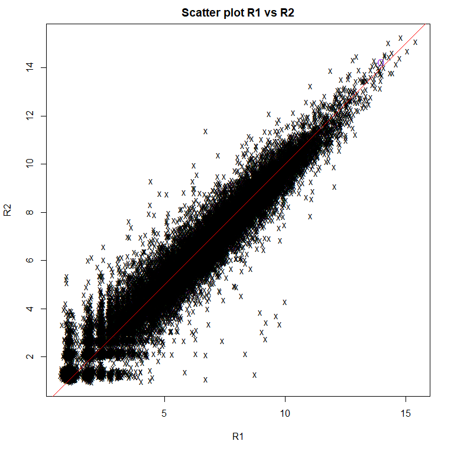

```r
TR.or <- read.table(file="res/TAIR_gene.tr")
gene.names <- unique(as.character(TR.or[,1]))
#Selecting transcript names for further analysis
transcript.names <- unique(as.character(TR.or[,2]))
pchs <- rep('x',length(gene.names))
cols <- rep('black',length(gene.names))
names(pchs) <- names(cols) <- gene.names
sel.gene <- "AT3G01150"
pchs[sel.gene] <- 'O'
cols[sel.gene] <- "purple"
plot(log2(OE.R1.g.exp+0.5), log2(OE.R2.g.exp+0.5),
     xlab="R1", ylab="R2",
     pch=pchs, col=cols,
     main="Scatter plot R1 vs R2")
abline(a=0,b=1, col="red")
```

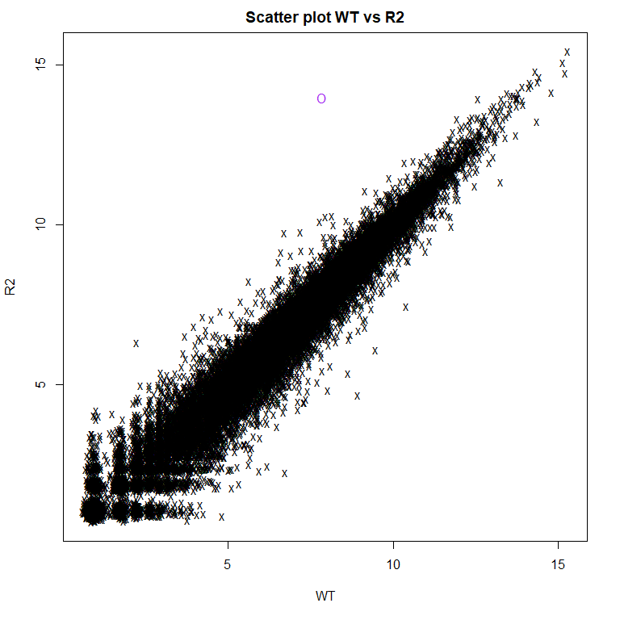

```r
plot(log2(WT.R1.g.exp+0.5), log2(OE.R1.g.exp+0.5),
     xlab="WT", ylab="R2",
     pch=pchs, col=cols,
     main="Scatter plot WT vs R2")
```

Value of expression for selected gene is clearly bigger in R2 when compared to WT

Visual analysis on transcript level

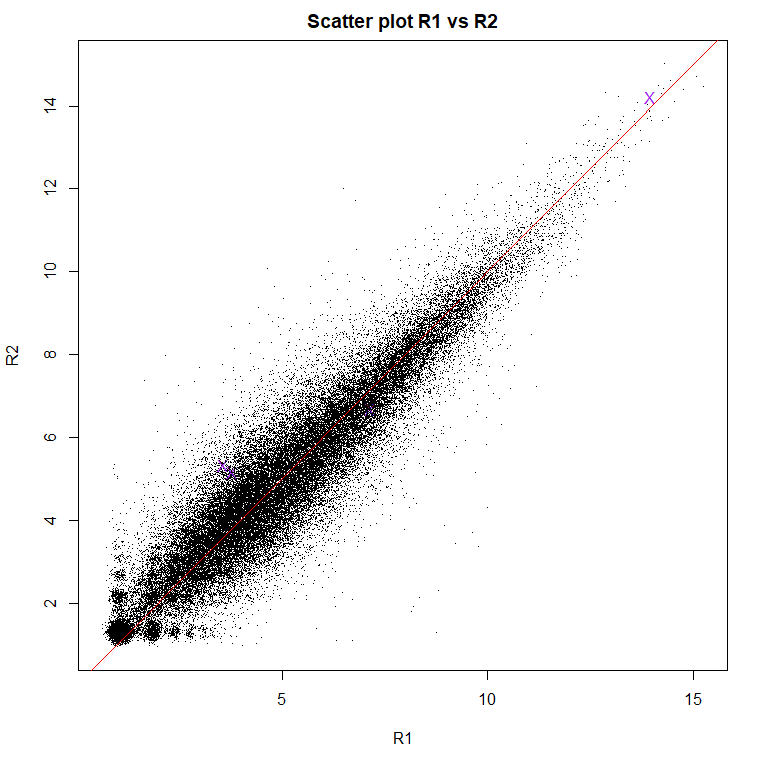

```r
pchs <- rep('.',dim(TR.or)[1])
cols <- rep('black',dim(TR.or)[1])
names(pchs) <- names(cols) <- as.character(TR.or[,2])
sel.gene <- "AT3G01150"
sel.trans <- as.character(TR.or[TR.or[,1]==sel.gene,2])
pchs[sel.trans] <- 'X'
cols[sel.trans] <- "purple"
plot(log2(OE.R1.t.exp+0.5), log2(OE.R2.t.exp+0.5),
     xlab="R1", ylab="R2",
     pch=pchs, col=cols,
     main="Scatter plot R1 vs R2")
abline(a=0,b=1, col="red")
```

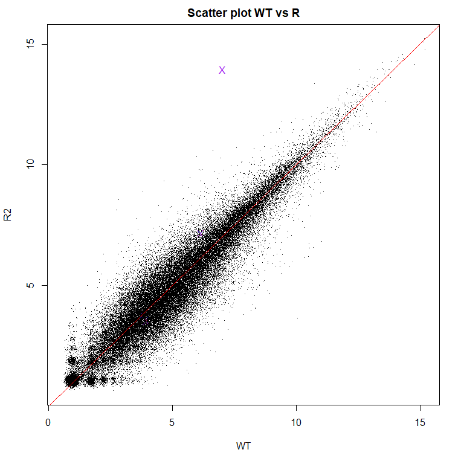

```r
plot(log2(WT.R1.t.exp+0.5), log2(OE.R1.t.exp+0.5),
     xlab="WT", ylab="R2",
     pch=pchs, col=cols,
     main="Scatter plot WT vs R")
abline(a=0,b=1, col="red")
```

Same observations on transcript level. Change of point characters was performed for better visualization.

Visual analysis between same examples (gene vs transcript)

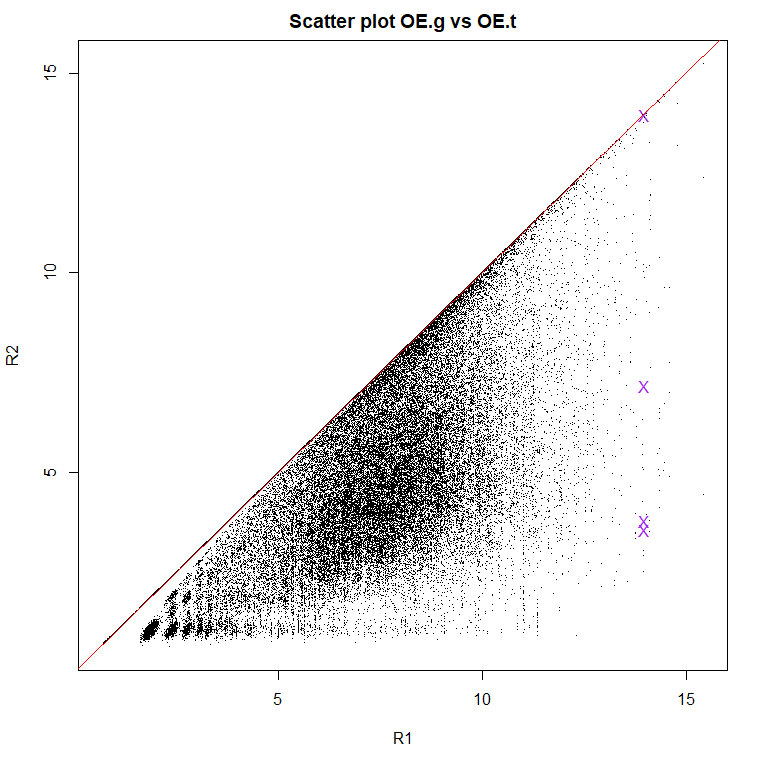

```r
names(OE.R1.g.exp) <- gene.names
plot(log2(OE.R1.g.exp[as.character(TR.or[,1])]+0.5), log2(OE.R1.t.exp+0.5),
     xlab="R1", ylab="R2",
     pch=pchs, col=cols,
     main="Scatter plot OE.g vs OE.t")
abline(a=0,b=1, col="red")
```

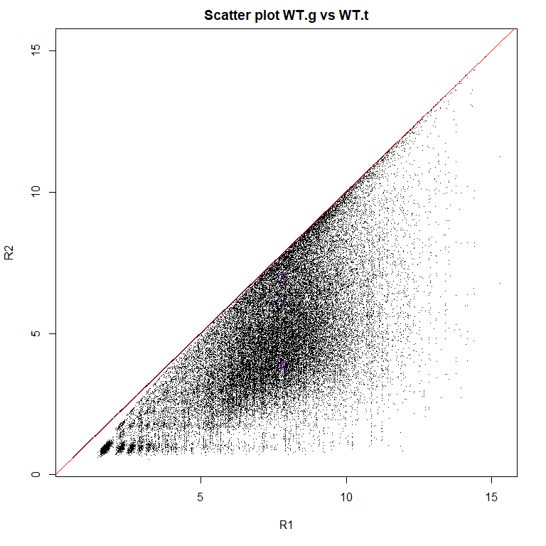

```r
names(WT.R1.g.exp) <- gene.names
plot(log2(WT.R1.g.exp[as.character(TR.or[,1])]+0.5), log2(WT.R1.t.exp+0.5),
     xlab="R1", ylab="R2",
     pch=pchs, col=cols,
     main="Scatter plot WT.g vs WT.t")
abline(a=0,b=1, col="red")
```

In Wild type hadn’t had any overexpression in selected genes. On the other hand modified organism had one transcript standing out from others and overall increased gene expression.

# Part 3: Part 3: Analysis with Bioconductor packages (limma, edgeR, DESeq2)

Importing necessary libraries

```r
BiocManager::install("limma", version = "3.8")
BiocManager::install("edgeR", version = "3.8")
BiocManager::install("DESeqa2", version = "3.8")
BiocManager::install("GenomeInfoDb", version = "3.8")
```

```r
library(limma)
library(edgeR)
library(DESeq2)
```

## Analysis using limma

**On gene level**

```r
##Limma GENES
names(OE.R1.g.exp) <- names(OE.R2.g.exp) <- names(WT.R1.g.exp) <- names(WT.R2.g.exp) <- gene.names
genes.merged <- cbind(OE.R1.g.exp, OE.R2.g.exp, WT.R1.g.exp, WT.R2.g.exp)
colnames(genes.merged) <-  c("OE.R1", "OE.R2", "WT.R1", "WT.R2")

samples <-  substr(colnames(genes.merged), 0, 2)
design <-  data.frame(OEs = ifelse(samples=="OE",1,0),
                      WTs=ifelse(samples=="WT",1,0))
rownames(design) <- colnames(genes.merged)
cm <-  makeContrasts(OEvsWT = OEs-WTs,
                     levels = design)
dge <-  DGEList(counts=genes.merged)
dge <-  calcNormFactors(dge)
```

```r
summary(dge$counts)
```

```
     OE.R1              OE.R2              WT.R1
 Min.   :    1.11   Min.   :    1.43   Min.   :    1.01
 1st Qu.:   15.97   1st Qu.:   16.32   1st Qu.:   19.63
 Median :   99.14   Median :   93.21   Median :  108.21
 Mean   :  330.82   Mean   :  315.28   Mean   :  326.19
 3rd Qu.:  307.97   3rd Qu.:  288.51   3rd Qu.:  312.32
 Max.   :43984.24   Max.   :39150.42   Max.   :40276.70
     WT.R2
 Min.   :    1.27
 1st Qu.:   16.54
 Median :   92.47
 Mean   :  333.44
 3rd Qu.:  293.76
 Max.   :53040.35
```

```r
v <-  voom(dge, design, plot=FALSE)
```

```r
summary(v$E)
```

```
     OE.R1            OE.R2            WT.R1            WT.R2
 Min.   :-2.295   Min.   :-1.987   Min.   :-2.417   Min.   :-2.107
 1st Qu.: 1.062   1st Qu.: 1.137   1st Qu.: 1.319   1st Qu.: 1.163
 Median : 3.659   Median : 3.614   Median : 3.752   Median : 3.611
 Mean   : 3.173   Mean   : 3.197   Mean   : 3.223   Mean   : 3.207
 3rd Qu.: 5.290   3rd Qu.: 5.239   3rd Qu.: 5.276   3rd Qu.: 5.274
 Max.   :12.446   Max.   :12.321   Max.   :12.285   Max.   :12.768
```

```r
f.t <- lmFit(v, design)
cf <- contrasts.fit(f.t, cm)
fe <- eBayes(cf, proportion=0.01)
adj.method='BH'
limma.countsTMMvoom.genes <- topTable(fe, number=Inf, adjust.method=adj.method, sort.by="none")
```

```r
head(limma.countsTMMvoom.genes,10)
```

|  | logFC | AveExpr | t | P.Value | adj.P.Val | B |
| --- | --- | --- | --- | --- | --- | --- |
| AT1G01010 | -0.53794542 | 3.718514 | -1.6078652 | 0.1499230 | 0.9999874 | -4.509940 |
| AT1G01020 | -0.18055216 | 3.690605 | -0.5493838 | 0.5990546 | 0.9999874 | -4.651710 |
| AT1G01030 | 0.31707773 | 2.679654 | 0.7414928 | 0.4814453 | 0.9999874 | -4.622397 |
| AT1G01040 | 0.07503273 | 5.607778 | 0.2333715 | 0.8218495 | 0.9999874 | -4.693731 |
| AT1G01050 | -0.29063991 | 4.736211 | -0.7177476 | 0.4951213 | 0.9999874 | -4.645332 |
| AT1G01060 | 0.28077141 | 6.921076 | 0.4254800 | 0.6826871 | 0.9999874 | -4.671404 |
| AT1G01070 | -0.45222749 | 2.546769 | -0.9861132 | 0.3554672 | 0.9999874 | -4.599398 |
| AT1G01080 | 0.15054504 | 5.762841 | 0.4206539 | 0.6860534 | 0.9999874 | -4.680540 |
| AT1G01090 | 0.08780866 | 7.658573 | 0.2210635 | 0.8310685 | 0.9999874 | -4.675191 |
| AT1G01100 | -0.06148913 | 6.328684 | -0.1446205 | 0.8889026 | 0.9999874 | -4.693138 |

```r
sum(limma.countsTMMvoom.genes$adj.P.Val < 0.05)
which(limma.countsTMMvoom.genes$adj.P.Val < 0.05)
limma.countsTMMvoom.genes[which(limma.countsTMMvoom.genes$adj.P.Val < 0.05),]
```

[output not shown]

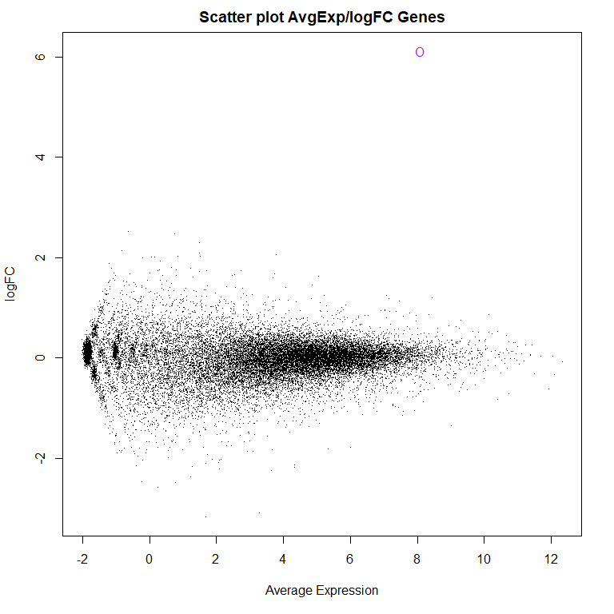

```r
pchs <- rep('.',length(gene.names))
cols <- rep('black',length(gene.names))
names(pchs) <- names(cols) <- gene.names
sel.gene <- "AT3G01150"
pchs[sel.gene] <- 'O'
cols[sel.gene] <- "purple"
plot(limma.countsTMMvoom.genes$AveExpr, limma.countsTMMvoom.genes$logFC,xlab='Average Expression', ylab='logFC',main = 'Scatter plot AvgExp/logFC Genes', pch=pchs, col=cols)
```

**On transcript level**

```r
## For transcripts


names(OE.R1.t.exp) <- names(OE.R2.t.exp) <- names(WT.R1.t.exp) <- names(WT.R2.t.exp) <- transcript.names
transcripts.merged <- cbind(OE.R1.t.exp, OE.R2.t.exp, WT.R1.t.exp, WT.R2.t.exp)
colnames(transcripts.merged) <-  c("OE.R1", "OE.R2", "WT.R1", "WT.R2")

samples <-  substr(colnames(transcripts.merged), 0, 2)
design <-  data.frame(OEs = ifelse(samples=="OE",1,0),
                      WTs=ifelse(samples=="WT",1,0))
rownames(design) <- colnames(transcripts.merged)
cm <-  makeContrasts(OEvsWT = OEs-WTs,
                     levels = design)
dge <-  DGEList(counts=transcripts.merged)
dge <-  calcNormFactors(dge)
```

```r
summary(dge$counts)
```

```
     OE.R1              OE.R2
 Min.   :    1.06   Min.   :    1.43
 1st Qu.:    8.11   1st Qu.:    8.39
 Median :   24.34   Median :   24.66
 Mean   :  137.76   Mean   :  131.28
 3rd Qu.:   86.75   3rd Qu.:   84.45
 Max.   :38655.88   Max.   :33305.85
     WT.R1              WT.R2
 Min.   :    0.95   Min.   :    1.27
 1st Qu.:    8.87   1st Qu.:    8.21
 Median :   26.44   Median :   24.17
 Mean   :  135.83   Mean   :  138.85
 3rd Qu.:   90.98   3rd Qu.:   83.96
 Max.   :37868.56   Max.   :41504.22
```

```r
v <-  voom(dge, design, plot=FALSE)
```

```r
summary(v$E)
```

```
     OE.R1             OE.R2
 Min.   :-2.3212   Min.   :-2.0085
 1st Qu.: 0.1428   1st Qu.: 0.1959
 Median : 1.6712   Median : 1.6961
 Mean   : 1.8811   Mean   : 1.9029
 3rd Qu.: 3.4838   3rd Qu.: 3.4516
 Max.   :12.2751   Max.   :12.0665
     WT.R1             WT.R2
 Min.   :-2.4642   Min.   :-2.117
 1st Qu.: 0.2303   1st Qu.: 0.185
 Median : 1.7548   Median : 1.687
 Mean   : 1.9159   Mean   : 1.901
 3rd Qu.: 3.5184   3rd Qu.: 3.462
 Max.   :12.2117   Max.   :12.403
```

```r
f.t <- lmFit(v, design)
cf <- contrasts.fit(f.t, cm)
fe <- eBayes(cf, proportion=0.01)
fe

adj.method='BH'
limma.countsTMMvoom.transcripts <- topTable(fe, number=Inf, adjust.method=adj.method, sort.by="none")
```

```r
head(limma.countsTMMvoom.transcripts)
```

|  | logFC | AveExpr | t | P.Value | adj.P.Val | B |
| --- | --- | --- | --- | --- | --- | --- |
| AT1G01010_ID1 | -0.54242855 | 3.7185140 | -1.15124132 | 0.2802747 | 0.9999965 | -4.587600 |
| AT1G01020_ID8 | -0.69001983 | 1.1104461 | -1.21252523 | 0.2571939 | 0.9999965 | -4.585733 |
| AT1G01020_ID9 | 0.05506893 | 1.8691504 | 0.09441678 | 0.9269158 | 0.9999965 | -4.618065 |
| AT1G01020_ID4 | 0.05099166 | 0.6151374 | 0.09345027 | 0.9276615 | 0.9999965 | -4.622177 |
| AT1G01020_ID5 | 0.11709142 | 0.7309135 | 0.20895226 | 0.8392935 | 0.9999965 | -4.620637 |
| AT1G01020_ID6 | 0.25316511 | 0.5328437 | 0.47884883 | 0.6438458 | 0.9999965 | -4.616095 |

```r
## X axis Average Expression
## Y axis logFC
sum(limma.countsTMMvoom.transcripts$adj.P.Val < 0.05)
which(limma.countsTMMvoom.transcripts$adj.P.Val < 0.05)
limma.countsTMMvoom.transcripts[which(limma.countsTMMvoom.transcripts$adj.P.Val < 0.05),]
```

[output not shown]

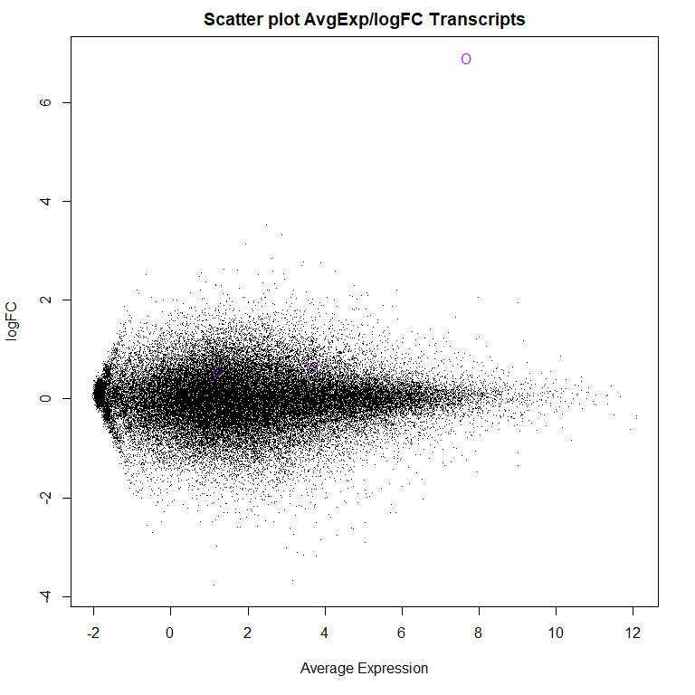

```r
pchs <- rep('.',dim(TR.or)[1])
cols <- rep('black',dim(TR.or)[1])
names(pchs) <- names(cols) <- as.character(TR.or[,2])
sel.gene <- "AT3G01150"
sel.trans <- as.character(TR.or[TR.or[,1]==sel.gene,2])
pchs[sel.trans] <- 'O'
cols[sel.trans] <- "purple"
plot(limma.countsTMMvoom.transcripts$AveExpr, limma.countsTMMvoom.transcripts$logFC,xlab='Average Expression', ylab='logFC', main='Scatter plot AvgExp/logFC Transcripts' , pch=pchs, col=cols)
```

**Summary**

The simpliest (in usage) method of analysis. Limma, built by the creators of edgeR (and using it as backbone) analyses data by gene-wise building linear models. For each gene there is a vector of gene expression values (provided in dataset), design matrix that serves as metadata to these values and the coefficients of interest. In analyses entire experiments as an integrated whole (without splitting data into batches). It allows to model correlations that may exist between samples due to redundant mesures or other causes. Limma does not serve as model for series of pairwise comparisons.

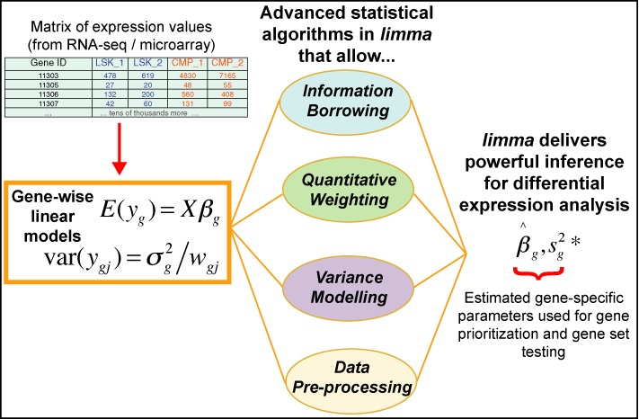

More on limma

## Analysis using DESeq2

**On gene level**

```r
##For Genes
OE.R1.g.exp.int <- as.integer(OE.R1.g.exp)
OE.R2.g.exp.int <- as.integer(OE.R2.g.exp)
WT.R1.g.exp.int <- as.integer(WT.R1.g.exp)
WT.R2.g.exp.int <- as.integer(WT.R2.g.exp)

##For Genes

names(OE.R1.g.exp.int) <- names(OE.R2.g.exp.int) <- names(WT.R1.g.exp.int) <- names(WT.R2.g.exp.int) <- gene.names
genes.merged <- cbind(OE.R1.g.exp.int, OE.R2.g.exp.int, WT.R1.g.exp.int, WT.R2.g.exp.int)
colnames(genes.merged) <-  c("OE.R1", "OE.R2", "WT.R1", "WT.R2")

samples <- substr(colnames(genes.merged), 0, 2)
head(genes.merged)

coldata <- data.frame(condition=samples, type=rep('single-end',4))
rownames(coldata) <- colnames(genes.merged)
head(coldata)


names(coldata)

design <-  data.frame(OEs =
                      ifelse(samples=="OE",1,0),
                  WTs=ifelse(samples=="WT",1,0))
rownames(design) <- colnames(genes.merged)

dds <- DESeqDataSetFromMatrix(genes.merged, coldata, ~ condition)
dds <- DESeq(dds)
```

```r
resultsNames(dds)
```

```
[1] "Intercept"
[2] "condition_WT_vs_OE"
```

```r
resn <- results(dds)
resn[sel.gene,]
```

```
log2 fold change (MLE): condition WT vs OE
Wald test p-value: condition WT vs OE
DataFrame with 1 row and 6 columns
                  baseMean
                 <numeric>
AT3G01150 9043.53306258812
             log2FoldChange
                  <numeric>
AT3G01150 -6.12673623120252
                      lfcSE
                  <numeric>
AT3G01150 0.403077540445245
                       stat
                  <numeric>
AT3G01150 -15.1998948500947
                        pvalue
                     <numeric>
AT3G01150 3.54189111135069e-52
                          padj
                     <numeric>
AT3G01150 8.46689070168382e-48
```

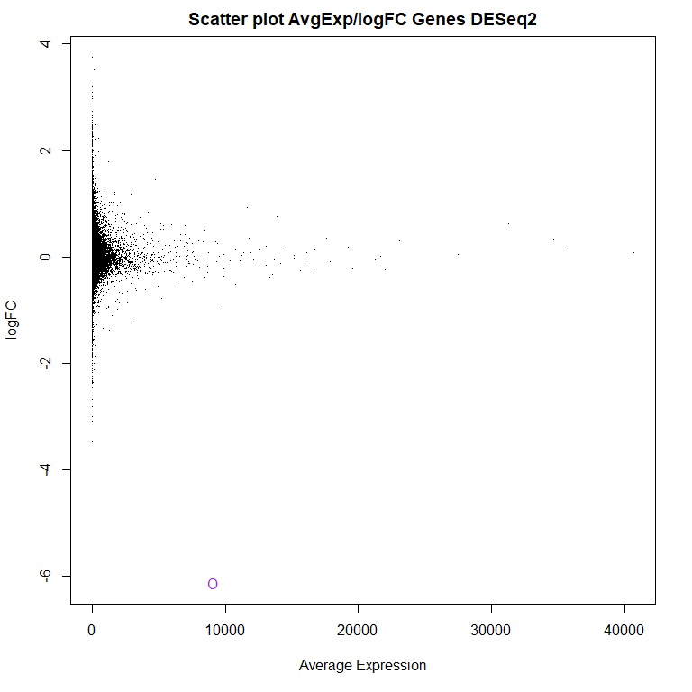

```r
pchs <- rep('.',length(gene.names))
cols <- rep('black',length(gene.names))
names(pchs) <- names(cols) <- gene.names
sel.gene <- "AT3G01150"
pchs[sel.gene] <- 'O'
cols[sel.gene] <- "purple"
plot(resn$baseMean, resn$log2FoldChange,xlab='Average Expression', ylab='logFC', main='Scatter plot AvgExp/logFC Genes DESeq2' , pch=pchs, col=cols)
```

**On transcript level**

```r
## For transcripts
OE.R1.t.exp.int <- as.integer(OE.R1.t.exp)
OE.R2.t.exp.int <- as.integer(OE.R2.t.exp)
WT.R1.t.exp.int <- as.integer(WT.R1.t.exp)
WT.R2.t.exp.int <- as.integer(WT.R2.t.exp)

names(OE.R1.t.exp.int) <- names(OE.R2.t.exp.int) <- names(WT.R1.t.exp.int) <- names(WT.R2.t.exp.int) <- transcript.names
transcripts.merged <- cbind(OE.R1.t.exp.int, OE.R2.t.exp.int, WT.R1.t.exp.int, WT.R2.t.exp.int)
colnames(transcripts.merged) <-  c("OE.R1", "OE.R2", "WT.R1", "WT.R2")


samples <- substr(colnames(transcripts.merged), 0, 2)
head(transcripts.merged)

coldata <- data.frame(condition=samples, type=rep('single-end',4))
rownames(coldata) <- colnames(genes.merged)

design <-  data.frame(OEs =
                      ifelse(samples=="OE",1,0),
                  WTs=ifelse(samples=="WT",1,0))

rownames(design) <- colnames(transcripts.merged)
coldata
dds <- DESeqDataSetFromMatrix(transcripts.merged, coldata, ~ condition)
dds <- DESeq(dds)
```

```r
resultsNames(dds)
```

```
[1] "Intercept"
[2] "condition_WT_vs_OE"
```

```r
resn <- results(dds)
sel.trans <- as.character(TR.or[TR.or[,1]==sel.gene,2])
```

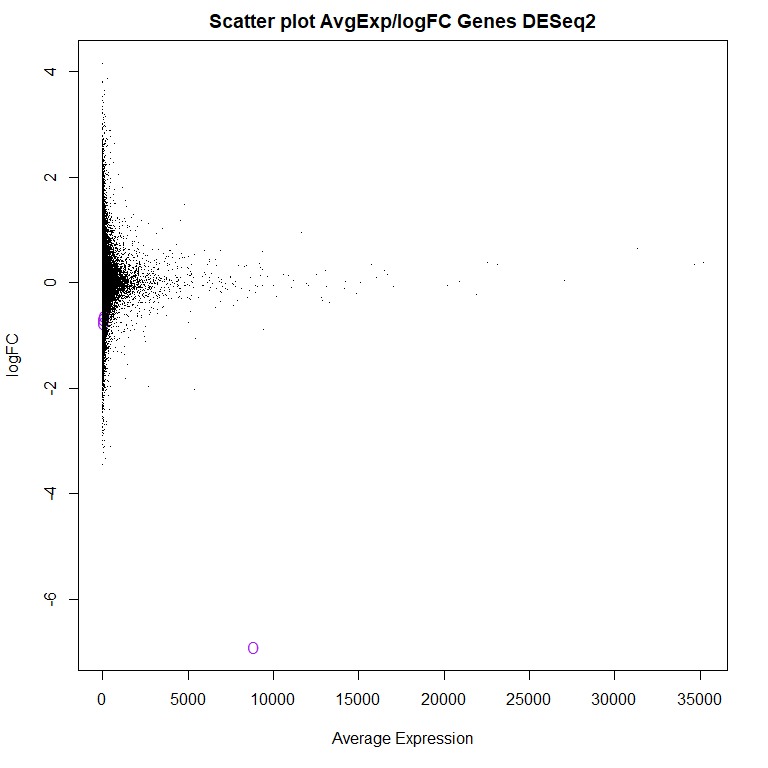

```r
pchs <- rep('.',dim(TR.or)[1])
cols <- rep('black',dim(TR.or)[1])
names(pchs) <- names(cols) <- as.character(TR.or[,2])
pchs[sel.trans] <- 'O'
cols[sel.trans] <- "purple"
plot(resn$baseMean, resn$log2FoldChange,xlab='Average Expression', ylab='logFC', main='Scatter plot AvgExp/logFC Genes DESeq2' , pch=pchs, col=cols)
```

```r
resn[sel.trans,]
```

```
log2 fold change (MLE): condition WT vs OE
Wald test p-value: condition WT vs OE
DataFrame with 4 rows and 6 columns
                      baseMean
                     <numeric>
AT3G01150_ID3 20.2869577003937
AT3G01150_ID4 8822.61664365712
AT3G01150_ID1 19.0298676040193
AT3G01150_ID2 100.200354277903
                  log2FoldChange
                       <numeric>
AT3G01150_ID3 -0.683427085096621
AT3G01150_ID4  -6.89806150087154
AT3G01150_ID1 -0.772027638916726
AT3G01150_ID2 -0.638230561467455
                          lfcSE
                      <numeric>
AT3G01150_ID3 0.822777037897842
AT3G01150_ID4 0.541377948489425
AT3G01150_ID1  0.80719858572937
AT3G01150_ID2 0.590463472647891
                            stat
                       <numeric>
AT3G01150_ID3 -0.830634611343489
AT3G01150_ID4  -12.7416743148087
AT3G01150_ID1 -0.956428384000618
AT3G01150_ID2  -1.08089761862043
                            pvalue
                         <numeric>
AT3G01150_ID3    0.406180075909006
AT3G01150_ID4 3.46869838331327e-37
AT3G01150_ID1    0.338855850219585
AT3G01150_ID2    0.279742658063708
                              padj
                         <numeric>
AT3G01150_ID3                   NA
AT3G01150_ID4 7.55898751691627e-33
AT3G01150_ID1                   NA
AT3G01150_ID2    0.999995544613067
```

**Summary** DESeq2 provides analysis using differential expression by using generalized negative binomial linear models. Results obtained by DESeq2 are different than those obtained by limma or edgeR because of that, for example on the plots we can see that gene and transcript of interest are marked on negative scale of logFC axis. Average expression axis also differs. To fully understand how exactly DESeq2 works one must study this publication. Some may say that DESeq2 is state of the art.

## Analysonesis using edgeR

**On gene level**

```r
##edgeR genes

names(OE.R1.g.exp) <- names(OE.R2.g.exp) <- names(WT.R1.g.exp) <- names(WT.R2.g.exp) <- gene.names
genes.merged <- cbind(OE.R1.g.exp, OE.R2.g.exp, WT.R1.g.exp, WT.R2.g.exp)
colnames(genes.merged) <-  c("OE.R1", "OE.R2", "WT.R1", "WT.R2")

samples <-  substr(colnames(genes.merged), 0, 2)
design <-  data.frame(OEs = ifelse(samples=="OE",1,0),
                      WTs=ifelse(samples=="WT",1,0))
rownames(design) <- colnames(genes.merged)

dge <- DGEList(counts=genes.merged)
dge <- calcNormFactors(dge)
dge <- estimateDisp(dge, design)

fit <- glmQLFit(dge, design)
lrt <- glmLRT(fit)
cm <-  makeContrasts(OEvsWT = OEs-WTs,
                     levels = design)
qlf <- glmQLFTest(fit, contrast=cm)
```

```r
topTags(qlf)
```

```
Coefficient:  1*OEs -1*WTs
```

|  | logFC | logCPM | F | PValue | FDR |
| --- | --- | --- | --- | --- | --- |
| AT3G01150 | 6.119933 | 10.1746990 | 78.56464 | 3.484446e-05 | 0.8329569 |
| AT3G12500 | -2.198427 | 4.7442598 | 44.28186 | 2.325001e-04 | 0.9999783 |
| AT4G10695 | 2.764878 | 0.1455457 | 33.94452 | 5.375007e-04 | 0.9999783 |
| AT5G35935 | -3.098824 | 2.4909325 | 28.68538 | 8.980527e-04 | 0.9999783 |
| AT2G13570 | 2.356960 | -0.1073947 | 27.22500 | 1.049974e-03 | 0.9999783 |
| AT4G21400 | 2.009275 | 4.1700084 | 25.52751 | 1.270281e-03 | 0.9999783 |
| AT1G43800 | -3.478182 | 4.3565580 | 24.77747 | 1.386336e-03 | 0.9999783 |
| AT1G48750 | -2.247624 | 2.5327309 | 23.34533 | 1.648124e-03 | 0.9999783 |
| AT3G20450 | 2.122774 | 0.5962435 | 21.64781 | 2.045959e-03 | 0.9999783 |
| AT1G64780 | -1.829767 | 3.9839678 | 21.57705 | 2.065071e-03 | 0.9999783 |

```r
edgeR.genes <- topTags(qlf)
edgeR.genes <- qlf$table
head(edgeR.genes,10)
```

|  | logFC | logCPM | F | PValue |
| --- | --- | --- | --- | --- |
| AT1G01010 | -0.54666927 | 3.769312 | 2.54429922 | 0.1526387 |
| AT1G01020 | -0.18552715 | 3.716854 | 0.29744194 | 0.6016244 |
| AT1G01030 | 0.36262317 | 2.756383 | 0.62711621 | 0.4531839 |
| AT1G01040 | 0.06677116 | 5.628723 | 0.04926951 | 0.8303747 |
| AT1G01050 | -0.35586633 | 4.807238 | 0.81459604 | 0.3953480 |
| AT1G01060 | 0.66163989 | 7.165680 | 1.07010584 | 0.3337174 |
| AT1G01070 | -0.52006625 | 2.651978 | 1.14147229 | 0.3191333 |
| AT1G01080 | 0.12510938 | 5.799609 | 0.13695661 | 0.7217488 |
| AT1G01090 | 0.10690462 | 7.697068 | 0.07357251 | 0.7936571 |
| AT1G01100 | -0.10118961 | 6.394129 | 0.06200503 | 0.8101628 |

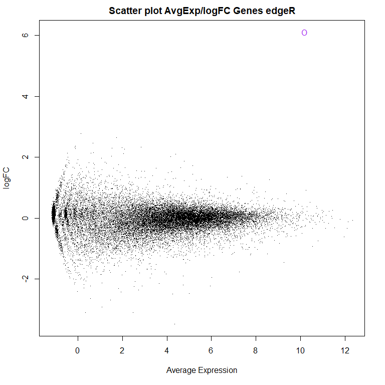

```r
pchs <- rep('.',length(gene.names))
cols <- rep('black',length(gene.names))
names(pchs) <- names(cols) <- gene.names
sel.gene <- "AT3G01150"
pchs[sel.gene] <- 'O'
cols[sel.gene] <- "purple"
plot(edgeR.genes$logCPM,edgeR.genes$logFC,xlab='Average Expression', ylab='logFC',main = 'Scatter plot AvgExp/logFC Genes edgeR', pch=pchs, col=cols)
```

**On transcript level**

```r
##edgeR Transcripts

names(OE.R1.t.exp) <- names(OE.R2.t.exp) <- names(WT.R1.t.exp) <- names(WT.R2.t.exp) <- transcript.names
transcripts.merged <- cbind(OE.R1.t.exp, OE.R2.t.exp, WT.R1.t.exp, WT.R2.t.exp)
colnames(transcripts.merged) <-  c("OE.R1", "OE.R2", "WT.R1", "WT.R2")

samples <-  substr(colnames(transcripts.merged), 0, 2)
design <-  data.frame(OEs = ifelse(samples=="OE",1,0),
                      WTs=ifelse(samples=="WT",1,0))
rownames(design) <- colnames(transcripts.merged)
cm <-  makeContrasts(OEvsWT = OEs-WTs,
                     levels = design)

dge <- DGEList(counts=transcripts.merged)
dge <- calcNormFactors(dge)
dge <- estimateDisp(dge, design)

fit <- glmQLFit(dge, design)
lrt <- glmLRT(fit)
cm <-  makeContrasts(OEvsWT = OEs-WTs,
                     levels = design)
qlf <- glmQLFTest(fit, contrast=cm)
```

```r
topTags(qlf)
```

```
Coefficient:  1*OEs -1*WTs
```

|  | logFC | logCPM | F | PValue | FDR |
| --- | --- | --- | --- | --- | --- |
| AT3G01150_ID4 | 6.903484 | 10.1475066 | 121.91728 | 1.225012e-06 | 0.07032548 |
| AT4G14880_ID19 | -2.868552 | 5.7194512 | 38.39429 | 1.412400e-04 | 0.99998580 |
| AT4G01800_ID1 | -2.679824 | 5.3169646 | 36.27162 | 1.752132e-04 | 0.99998580 |
| AT5G10720_ID4 | -2.798185 | 0.1756749 | 31.77290 | 2.868918e-04 | 0.99998580 |
| AT2G36530_ID120 | 2.779357 | 4.0838913 | 30.39789 | 3.373048e-04 | 0.99998580 |
| AT3G10970_ID10 | -2.776792 | 3.7970379 | 30.38467 | 3.378394e-04 | 0.99998580 |
| AT3G52220_ID3 | 2.682975 | 3.9854509 | 30.21272 | 3.448910e-04 | 0.99998580 |
| AT5G35935_ID1 | -3.809611 | 2.1827530 | 29.52519 | 3.749390e-04 | 0.99998580 |
| AT4G10695_ID1 | 2.758523 | 0.1442991 | 29.09369 | 3.954303e-04 | 0.99998580 |
| AT5G52650_ID2 | -2.574856 | 5.2765874 | 27.71045 | 4.709836e-04 | 0.99998580 |

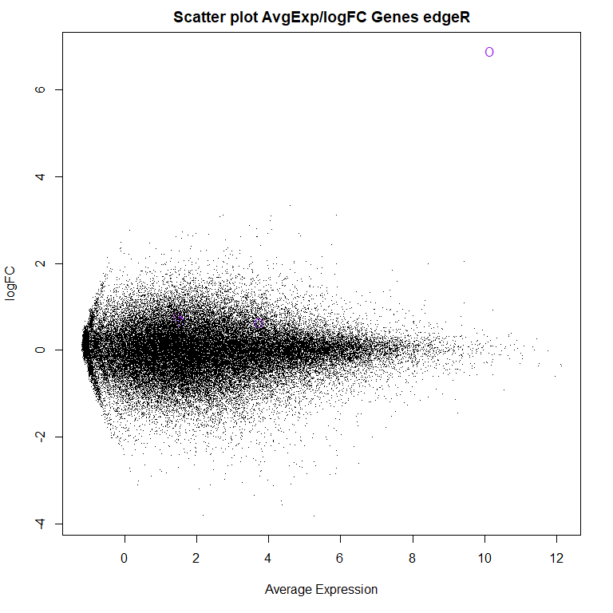

```r
edgeR.transcripts <- qlf$table
sel.gene <- "AT3G01150"
pchs <- rep('.',dim(TR.or)[1])
cols <- rep('black',dim(TR.or)[1])
names(pchs) <- names(cols) <- as.character(TR.or[,2])
sel.gene <- "AT3G01150"
sel.trans <- as.character(TR.or[TR.or[,1]==sel.gene,2])
pchs[sel.trans] <- 'O'
cols[sel.trans] <- "purple"
plot(edgeR.transcripts$logCPM,edgeR.transcripts$logFC,xlab='Average Expression', ylab='logFC',main = 'Scatter plot AvgExp/logFC Genes edgeR', pch=pchs, col=cols)
```

**Summary**

edgeR for limma is like Tensorflow for Pytorch. Low level Data analysis module that can provide the same solution analogous functions and results as higher level (and newer) one. edgeR counts data by using an overdispersed Poisson model, then uses emirical Bayes analysis procedure to moredate the degree of orevdispersion actoss genes. Data is modeled as negative distributed.

## Conclusions

Easies way to perform analysis was provided by limma. Real reasons why DESeq2 models logFC output as negative of edgeR or limma is still a mystery to me and I’ll find it out after exams

## Conclusion about course:

Using jupyter notebook or RStudio instead of emacs could be easier for most of participants. Output produced by them is more human-readible for those who just started their journey with programming.